# Exploring Meteorological Influences on Solar Radiation in the Northeast United States

## Summer 2024 Data Science Project

### Group Members:

- Muhammad Ramamni
- Shrawan Gopal
- James Heiser
- Alexander Cruz

## 1. Introduction

In this project, we aim to analyze the relationship between various meteorological parameters and global horizontal radiation across three cities in the Northeast United States: Hartford, CT; Caribou, ME; and Philadelphia, PA. Specifically, our analysis is divided into four main sections:

### Heatmap of 12 Weather Variables

We examine the correlations among twelve weather variables, including: Dry Bulb Temperature, Dew Point Temperature, Relative Humidity, Atmospheric Station Pressure, Wind Direction, Wind Speed, Total Sky Cover, Opaque Sky Cover, Visibility, Ceiling Height, Precipitable Water, and Global Horizontal Radiation.

**Importance**: Visualizing the correlations among these weather variables helps us understand the complex interactions between different meteorological factors and their combined effect on solar radiation. This comprehensive analysis is crucial for optimizing solar energy production.

### Dry Bulb Temperature in January vs July

We compare the dry bulb temperature during the months of January and July to understand seasonal variations and their potential impact on global horizontal radiation.

**Importance**: Understanding seasonal variations in dry bulb temperature helps optimize solar energy systems for different times of the year. This knowledge is crucial for maximizing solar energy production and efficiency throughout the year.

### Total Sky Cover vs Global Horizontal Radiation

This section examines the relationship between total sky cover and global horizontal radiation to determine how cloud cover affects solar radiation received at the surface.

**Importance**: Analyzing the impact of sky cover on solar radiation is essential for predicting solar energy production and improving the design and placement of solar panels. This information can help in optimizing energy capture and storage systems.

### Dry Bulb Temperature vs Global Horizontal Radiation

We investigate the correlation between dry bulb temperature and global horizontal radiation, providing insights into how temperature variations influence solar radiation.

**Importance**: By understanding how dry bulb temperature correlates with solar radiation, we can develop predictive models to anticipate maintenance needs and optimize the performance of solar energy systems based on temperature variations.

## Our Primary Questions

1. What are the significant correlations among the 12 weather variables, and how do they interact with global horizontal radiation?
2. How does the dry bulb temperature vary between January and July?
3. What is the relationship between total sky cover and global horizontal radiation?
4. How does dry bulb temperature correlate with global horizontal radiation?

## Objectives

- **Analyze Seasonal Variations in Solar Energy Potential**
- **Assess the Impact of Weather on Energy Efficiency**
- **Forecast Solar Energy Production**

By addressing these questions and objectives, we aim to better understand the climatic factors influencing solar radiation, which is crucial for renewable energy applications and climate modeling. Additionally, understanding these relationships can help in improving weather forecasting models and developing strategies to mitigate the effects of climate change.

## 2. Data Curation

**Data Sources:** Merket, Noel. 2020. "Weather Data for Buildings Energy Simulations." NREL Data Catalog. Golden, CO: National Renewable Energy Laboratory. Last updated: December 12, 2023. DOI: 10.7799/1603006.

https://data.nrel.gov/submissions/128

NE_Weather_2018.zip:

- PA_PHILADELPHIA-IAP_724080_18.epw
- CT_HARTFORD-BRADLEY-IAP_725080_18.epw
- ME_CARIBOU-MUNI-AP_727120_18.epw

**Data Description:**

- Dry Bulb Temperature: The air temperature as measured by a thermometer freely exposed to the air.
- Dew Point Temperature: The temperature at which air becomes saturated with moisture.
- Relative Humidity: The amount of moisture in the air relative to the maximum amount the air can hold at that temperature.
- Atmospheric Station Pressure: The pressure exerted by the atmosphere at a given point.
- Wind Direction: The direction from which the wind is blowing.
- Wind Speed: The speed at which the wind is blowing.
- Total Sky Cover: The fraction of the sky covered by clouds.
- Opaque Sky Cover: The fraction of the sky covered by opaque clouds.
- Visibility: The distance one can clearly see.
- Ceiling Height: The height above ground level of the lowest layer of clouds.
- Precipitable Water: The total amount of water vapor in a column of air.
- Global Horizontal Radiation: The total amount of shortwave radiation received from above by a horizontal surface.

EPW File Structure: The EPW file structure is well-documented. It includes a header section and a data section. The header contains data about the weather station and data source, and the data section contains the actual weather data. The columns for the weather data section are standardized across all EPW files. These typically include various parameters like temperature, humidity, wind speed, and radiation

More information on EPW's and Variables here:

- https://designbuilder.co.uk/cahelp/Content/EnergyPlusWeatherFileFormat.htm#:~:text=The%20EnergyPlus%20data%20dictionary%20format,for%20alphanumeric%3B%20N%20for%20numeric
- https://bigladdersoftware.com/epx/docs/8-3/auxiliary-programs/energyplus-weather-file-epw-data-dictionary.html

**Data Transformation:**

```python
from google.colab import files
uploaded = files.upload()
```

Upload widget is only available when the cell has been executed in the current browser session. Please rerun this cell to enable.

```
Saving CT_HARTFORD-BRADLEY-IAP_725080_18.epw to CT_HARTFORD-BRADLEY-IAP_725080_18.epw
Saving ME_CARIBOU-MUNI-AP_727120_18.epw to ME_CARIBOU-MUNI-AP_727120_18.epw
Saving PA_PHILADELPHIA-IAP_724080_18.epw to PA_PHILADELPHIA-IAP_724080_18.epw
```

```python
import pandas as pd

# The columns based on EPW file structure
columns = [
    "Year", "Month", "Day", "Hour", "Minute", "Data Source and Uncertainty Flags",
    "Dry Bulb Temperature", "Dew Point Temperature", "Relative Humidity",
    "Atmospheric Station Pressure", "Extraterrestrial Horizontal Radiation",
    "Extraterrestrial Direct Normal Radiation", "Horizontal Infrared Radiation Intensity",
    "Global Horizontal Radiation", "Direct Normal Radiation", "Diffuse Horizontal Radiation",
    "Global Horizontal Illuminance", "Direct Normal Illuminance",
    "Diffuse Horizontal Illuminance", "Zenith Luminance", "Wind Direction", "Wind Speed",
    "Total Sky Cover", "Opaque Sky Cover", "Visibility", "Ceiling Height",
    "Present Weather Observation", "Present Weather Codes", "Precipitable Water",
    "Aerosol Optical Depth", "Snow Depth", "Days Since Last Snowfall", "Albedo",
    "Liquid Precipitation Depth", "Liquid Precipitation Quantity"
]


columns_to_drop = [
    "Data Source and Uncertainty Flags",
    "Albedo",
    "Liquid Precipitation Depth",
    "Liquid Precipitation Quantity",
    "Days Since Last Snowfall",
    "Present Weather Codes",
    "Aerosol Optical Depth",
    "Snow Depth",
    "Present Weather Observation"
]

#  EPW -> CSV
def process_epw(file_path, csv_file_path):
    df = pd.read_csv(file_path, sep=',', skiprows=8, header=None, names=columns) # Reading the file, skipping the first 8 lines
    df = df.drop(columns=columns_to_drop)
    df.to_csv(csv_file_path, index=False)

# PHILADELPHIA
file_path_1 = '/content/PA_PHILADELPHIA-IAP_724080_18.epw'
csv_file_path_1 = '/content/PA_PHILADELPHIA_2018.csv'
process_epw(file_path_1, csv_file_path_1)

# HARTFORD
file_path_2 = '/content/CT_HARTFORD-BRADLEY-IAP_725080_18.epw'
csv_file_path_2 = '/content/CT_HARTFORD_2018.csv'
process_epw(file_path_2, csv_file_path_2)

# CARIBOU
file_path_3 = '/content/ME_CARIBOU-MUNI-AP_727120_18.epw'
csv_file_path_3 = '/content/ME_CARIBOU_2018.csv'
process_epw(file_path_3, csv_file_path_3)
```

## 3. Exploratory Data Analysis

```python
# Imports
from scipy.stats import mannwhitneyu
from scipy.stats import pearsonr
from scipy.stats import chi2_contingency
import matplotlib.pyplot as plt
import seaborn as sns

ct_hartford = pd.read_csv('/content/CT_HARTFORD_2018.csv')
pa_philadelphia = pd.read_csv('/content/PA_PHILADELPHIA_2018.csv')
me_caribou = pd.read_csv('/content/ME_CARIBOU_2018.csv')
```

A **heat map** is used to identify patterns and correlations between many different variables. We will use a heat map here to identify any correlation between 11 different features and Global Horizontal Radiation, a measure of solar energy, for each of the three cities. This will provide us with a comprehensive understanding of the relationship each weather variable has with each other and how they individually impact solar energy.

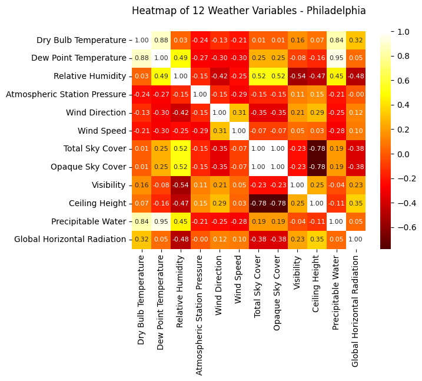

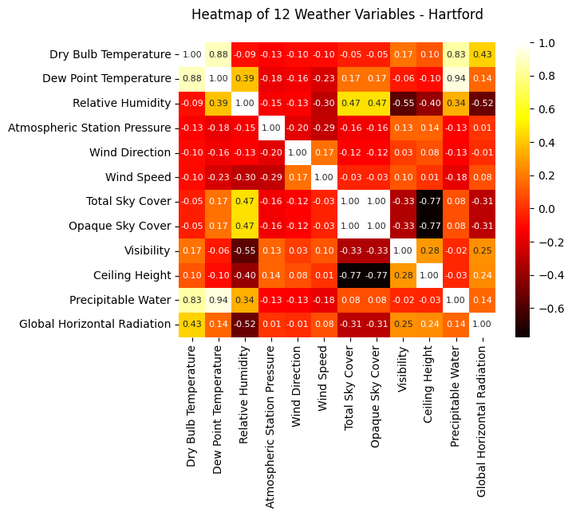

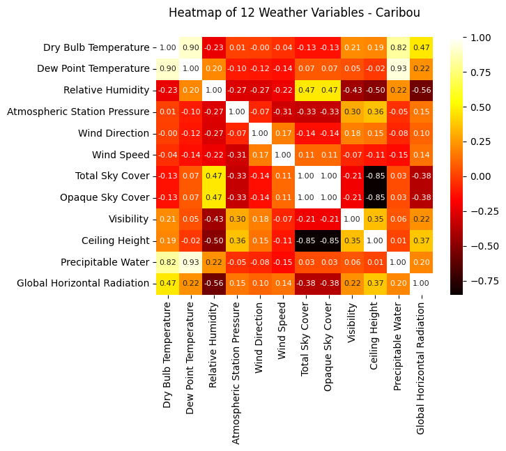

```python
variables = ["Dry Bulb Temperature", "Dew Point Temperature", "Relative Humidity",
          "Atmospheric Station Pressure", "Wind Direction", "Wind Speed", "Total Sky Cover",
          "Opaque Sky Cover", "Visibility", "Ceiling Height", "Precipitable Water",
          "Global Horizontal Radiation"]

philly_corr = pd.DataFrame()
for v in variables:
  philly_corr[v] = pa_philadelphia[pa_philadelphia["Global Horizontal Radiation"] != 0][v]
sns.heatmap(data= philly_corr.corr(), cmap = "hot", annot= True, fmt = '.2f', annot_kws={'size': 8}, center= 0)
plt.title("Heatmap of 12 Weather Variables - Philadelphia\n")
plt.show()

hartford_corr = pd.DataFrame()
for v in variables:
  hartford_corr[v] = ct_hartford[ct_hartford["Global Horizontal Radiation"] != 0][v]
sns.heatmap(data= hartford_corr.corr(), cmap = "hot", annot= True, fmt = '.2f', annot_kws={'size': 8})
plt.title("Heatmap of 12 Weather Variables - Hartford\n")
plt.show()

caribou_corr = pd.DataFrame()
for v in variables:
  caribou_corr[v] = me_caribou[me_caribou["Global Horizontal Radiation"] != 0][v]
sns.heatmap(data= caribou_corr.corr(), cmap = "hot", annot= True, fmt = '.2f', annot_kws={'size': 8})
plt.title("Heatmap of 12 Weather Variables - Caribou\n")
plt.show()
```

**Conclusion:** We can see that Relative Humidity is consistently the most influential feature, having a moderate correlation (defined by a correlation coefficient with an absolute value between about 0.5 and 0.75) with Sky Cover, Ceiling Height, Visibility, and Global Horizontal Radiation. Relative Humidity is also the only feature that seems to have a significant impact on solar energy, as no other feature has a moderate or stronger correlation with Global Horizontal Radiation. However, Dry Bulb Temperature does appear to have some impact on Global Horizontal Radiation, with a correlation coefficent ranging from 0.32 to 0.47 between the three heat maps.

The **Mann-Whitney U Test** is used to determine whether there is a significant difference between the distributions of two independent samples. In this case, we are comparing the Dry Bulb Temperature between January and July for each city.

In this part, we analyze the dry bulb temperature data for various cities to understand the seasonal variations and their implications on solar energy efficiency. By comparing the dry bulb temperatures in January and July, we can assess the impact of temperature fluctuations on solar energy systems.

The following analysis involves the use of the Mann-Whitney U Test to determine if there is a significant difference between the dry bulb temperatures in January and July for each city. This will help us understand the seasonal variations and their potential impact on solar energy generation.

```
Mann-Whitney U Test | HARTFORD, CONNECTICUT | P-value: 7.129733499728298e-244
Mann-Whitney U Test | CARIBOU, MAINE | P-value:  2.6201312666261812e-244
Mann-Whitney U Test | PHILADELPHIA, PENNSYLVANIA | P-value:  1.9659545989683085e-244
```

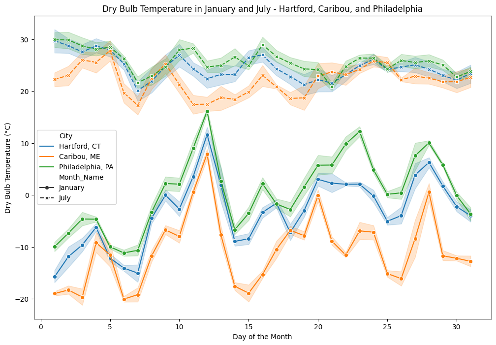

```python
winter = ct_hartford[ct_hartford['Month'] == 1]['Dry Bulb Temperature']
summer = ct_hartford[ct_hartford['Month'] == 7]['Dry Bulb Temperature']
print(f"Mann-Whitney U Test | HARTFORD, CONNECTICUT | P-value:", mannwhitneyu(winter, summer).pvalue)

winter = me_caribou[me_caribou['Month'] == 1]['Dry Bulb Temperature']
summer = me_caribou[me_caribou['Month'] == 7]['Dry Bulb Temperature']
print(f"Mann-Whitney U Test | CARIBOU, MAINE | P-value: ", mannwhitneyu(winter, summer).pvalue)

winter = pa_philadelphia[pa_philadelphia['Month'] == 1]['Dry Bulb Temperature']
summer = pa_philadelphia[pa_philadelphia['Month'] == 7]['Dry Bulb Temperature']
print(f"Mann-Whitney U Test | PHILADELPHIA, PENNSYLVANIA | P-value: ", mannwhitneyu(winter, summer).pvalue)

ct_hartford['City'] = 'Hartford, CT'
me_caribou['City'] = 'Caribou, ME'
pa_philadelphia['City'] = 'Philadelphia, PA'

combined_data = pd.concat([ct_hartford, me_caribou, pa_philadelphia])
combined_data = combined_data[combined_data['Month'].isin([1, 7])]

month_map = {1: 'January', 7: 'July'}
combined_data['Month_Name'] = combined_data['Month'].map(month_map)

# Line Graph
plt.figure(figsize=(12, 8))
sns.lineplot(x='Day', y='Dry Bulb Temperature', hue='City', style='Month_Name', markers=True, data=combined_data)
plt.title('Dry Bulb Temperature in January and July - Hartford, Caribou, and Philadelphia')
plt.xlabel('Day of the Month')
plt.ylabel('Dry Bulb Temperature (°C)')
plt.show()
```

**Conclusion:** Based on the extremely low p-values from the Mann-Whitney U tests for Hartford, Caribou, and Philadelphia, we can conclude that there is a statistically significant difference in dry bulb temperatures between January and July in each location. The p-values indicate that the differences are highly unlikely to be due to random chance, confirming a distinct seasonal variation in temperatures.

In Hartford and Philadelphia, July temperatures are significantly higher than in January, reflecting expected seasonal variations, with Philadelphia generally warmer due to its southern location. Caribou, further north, experiences a more pronounced seasonal difference with colder winters, impacting energy consumption patterns and solar energy potential, as illustrated by the line plot showing distinct temperature trends across all three cities.

This analysis which calculates the **Pearson Correlation Coefficient** will help us compare the impact of Total Sky Cover on Global Horizontal Radiation across different locations. This analysis will tell us the fraction of the sky covered by clouds compared to the total amount of shortwave radiation received from above by a horizontal surface in 1 year based on location.

- Coefficient: Indicates the average change in Global Horizontal Radiation for a one-unit change in Total Sky Cover.
- Intercept: The estimated Global Horizontal Radiation when Total Sky Cover is zero.
- MSE (Mean Squared Error): The average squared difference between the actual and predicted values.
- R² (R-squared): The proportion of the variance in the dependent variable that is predictable from the independent variable.

```
Hartford, CT:
Pearson Correlation Coefficient: -0.07802312112004263
P-value: 2.6188366990425606e-13
```

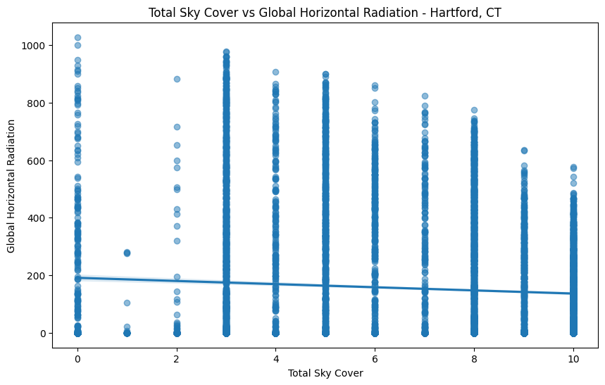

```
Caribou, ME:
Pearson Correlation Coefficient: -0.2015082198906349
P-value: 6.180026562906335e-81
```

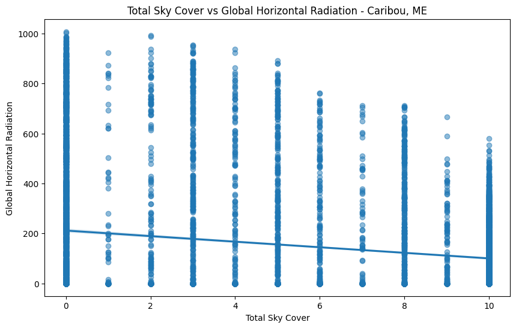

```
Philadelphia, PA:
Pearson Correlation Coefficient: -0.1253260791604027
P-value: 5.27333561927901e-32
```

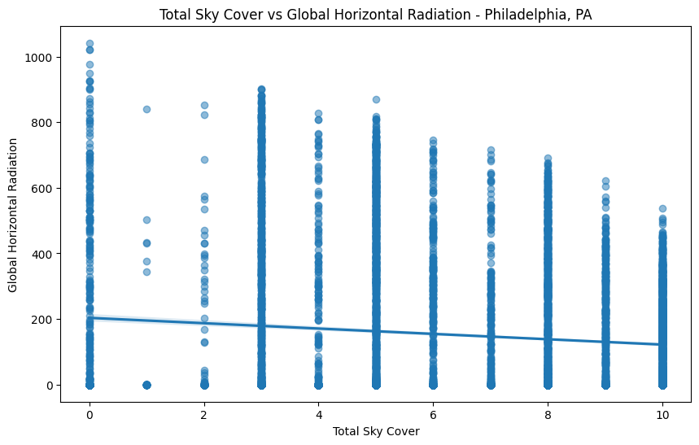

```python
# Function to perform analysis
def analyze_sky_cover_vs_radiation(data, location_name):
    sky_cover = data['Total Sky Cover']
    global_radiation = data['Global Horizontal Radiation']

    # Calculate the Pearson correlation coefficient
    corr_coef, p_value = pearsonr(sky_cover, global_radiation)

    print(f"{location_name}:")
    print(f"Pearson Correlation Coefficient: {corr_coef}")
    print(f"P-value: {p_value}\n")

    # Scatter plot with regression line
    plt.figure(figsize=(10, 6))
    sns.regplot(x=sky_cover, y=global_radiation, scatter_kws={'alpha':0.5})
    plt.title(f'Total Sky Cover vs Global Horizontal Radiation - {location_name}')
    plt.xlabel('Total Sky Cover')
    plt.ylabel('Global Horizontal Radiation')
    plt.show()

# Perform analysis for each location
analyze_sky_cover_vs_radiation(ct_hartford, 'Hartford, CT')
analyze_sky_cover_vs_radiation(me_caribou, 'Caribou, ME')
analyze_sky_cover_vs_radiation(pa_philadelphia, 'Philadelphia, PA')
```

A **chi-squared test** is used to determine whether there is a significant association between categorical variables. It compares the observed frequencies of categorical data against the frequencies that would be expected if the variables were independent. In this case, we use the chi-squared test to determine whether there is an association between Dry Bulb Temperature and Global Horizontal Radiation, and the strength of this association.

```
Chi-square value: 1818.7222145163767
P-value: 0.0
Degrees of freedom: 45
Expected frequencies:
 [[470.57191781  93.79280822  93.79280822  93.3640411   93.68561644
   93.79280822]
 [421.46004566  84.00399543  84.00399543  83.61997717  83.90799087
   84.00399543]
 [441.00456621  87.89954338  87.89954338  87.49771689  87.79908676
   87.89954338]
 [439.50114155  87.59988584  87.59988584  87.19942922  87.49977169
   87.59988584]
 [423.46461187  84.40353881  84.40353881  84.01769406  84.30707763
   84.40353881]
 [439.50114155  87.59988584  87.59988584  87.19942922  87.49977169
   87.59988584]
 [444.01141553  88.49885845  88.49885845  88.09429224  88.39771689
   88.49885845]
 [447.51940639  89.19805936  89.19805936  88.7902968   89.09611872
   89.19805936]
 [425.97031963  84.90296804  84.90296804  84.51484018  84.80593607
   84.90296804]
 [436.99543379  87.10045662  87.10045662  86.70228311  87.00091324
   87.10045662]]
```

[figure not shown]

```
Chi-square value: 2528.2624291523252
P-value: 0.0
Degrees of freedom: 45
Expected frequencies:
 [[444.22157534  85.57842466  88.50159817  89.00559361  87.79600457
   87.89680365]
 [441.70616438  85.09383562  88.00045662  88.50159817  87.29885845
   87.39908676]
 [481.44965753  92.75034247  95.91849315  96.46472603  95.15376712
   95.2630137 ]
 [395.42260274  76.17739726  78.77945205  79.22808219  78.15136986
   78.24109589]
 [440.7         84.9         87.8         88.3         87.1
   87.2       ]
 [446.7369863   86.0630137   89.00273973  89.50958904  88.29315068
   88.39452055]
 [450.76164384  86.83835616  89.80456621  90.31598174  89.08858447
   89.19086758]
 [458.8109589   88.3890411   91.40821918  91.92876712  90.67945205
   90.78356164]
 [410.0119863   78.9880137   81.68607306  82.15125571  81.03481735
   81.12785388]
 [437.17842466  84.22157534  87.09840183  87.59440639  86.40399543
   86.50319635]]
```

[figure not shown]

```
Chi-square value: 2189.534335569802
P-value: 0.0
Degrees of freedom: 45
Expected frequencies:
 [[441.00456621  85.79543379  88.10068493  87.59954338  87.8
   87.69977169]
 [465.11415525  90.48584475  92.91712329  92.38858447  92.6
   92.49429224]
 [437.48858447  85.11141553  87.39828767  86.90114155  87.1
   87.00057078]
 [423.92694064  82.47305936  84.6890411   84.20730594  84.4
   84.30365297]
 [460.0913242   89.5086758   91.91369863  91.39086758  91.6
   91.49543379]
 [444.52054795  86.47945205  88.80308219  88.29794521  88.5
   88.3989726 ]
 [416.39269406  81.00730594  83.18390411  82.71073059  82.9
   82.8053653 ]
 [437.99086758  85.20913242  87.49863014  87.00091324  87.2
   87.10045662]
 [448.53881279  87.26118721  89.60582192  89.09611872  89.3
   89.19805936]
 [424.93150685  82.66849315  84.88972603  84.40684932  84.6
   84.50342466]]
```

[figure not shown]

```python
dry_bulbp = pa_philadelphia['Dry Bulb Temperature']
global_radp = pa_philadelphia['Global Horizontal Radiation']

dry_bulb_bin = pd.qcut(dry_bulbp, q=10, duplicates='drop')
global_rad_bin = pd.qcut(global_radp, q=10, duplicates='drop')

contingency_table = pd.crosstab(dry_bulb_bin, global_rad_bin)
chi2, p_value, dof, expected = chi2_contingency(contingency_table)

print(f'Chi-square value: {chi2}')
print(f'P-value: {p_value}')
print(f'Degrees of freedom: {dof}')
print(f'Expected frequencies:\n {expected}')

plt.figure(figsize=(14, 8))
plt.scatter(dry_bulbp, global_radp, alpha=0.5, edgecolors='w', s=20)
plt.title('Dry Bulb Temperature vs Global Horizontal Radiation (Philadelphia 2018)')
plt.xlabel('Dry Bulb Temperature (°F)')
plt.ylabel('Global Horizontal Radiation (W/m^2)')
plt.grid(True)
plt.show()
plt.figure(figsize=(20,10))
plt.title

dry_bulbh = ct_hartford['Dry Bulb Temperature']
global_radh = ct_hartford['Global Horizontal Radiation']

dry_bulb_bin = pd.qcut(dry_bulbh, q=10, duplicates='drop')
global_rad_bin = pd.qcut(global_radh, q=10, duplicates='drop')

contingency_table = pd.crosstab(dry_bulb_bin, global_rad_bin)
chi2, p_value, dof, expected = chi2_contingency(contingency_table)

print(f'Chi-square value: {chi2}')
print(f'P-value: {p_value}')
print(f'Degrees of freedom: {dof}')
print(f'Expected frequencies:\n {expected}')

plt.figure(figsize=(14, 8))
plt.scatter(dry_bulbh, global_radh, alpha=0.5, edgecolors='w', s=20, c='darkorange')
plt.title('Dry Bulb Temperature vs Global Horizontal Radiation (Hartford 2018)')
plt.xlabel('Dry Bulb Temperature (°F)')
plt.ylabel('Global Horizontal Radiation (W/m^2)')
plt.grid(True)
plt.show()

dry_bulbc = me_caribou['Dry Bulb Temperature']
global_radc = me_caribou['Global Horizontal Radiation']

dry_bulb_bin = pd.qcut(dry_bulbc, q=10, duplicates='drop')
global_rad_bin = pd.qcut(global_radc, q=10, duplicates='drop')

contingency_table = pd.crosstab(dry_bulb_bin, global_rad_bin)
chi2, p_value, dof, expected = chi2_contingency(contingency_table)

print(f'Chi-square value: {chi2}')
print(f'P-value: {p_value}')
print(f'Degrees of freedom: {dof}')
print(f'Expected frequencies:\n {expected}')

plt.figure(figsize=(14, 8))
plt.scatter(dry_bulbc, global_radc, alpha=0.5, edgecolors='w', s=20, c='green')
plt.title('Dry Bulb Temperature vs Global Horizontal Radiation (Hartford 2018)')
plt.xlabel('Dry Bulb Temperature (°F)')
plt.ylabel('Global Horizontal Radiation (W/m^2)')
plt.grid(True)
plt.show()
```

**Conclusion**: All three cities have a very low p-value, showing that the relationship between Dry Bulb Temperature and Global Horizontal Radiation is statistically significant. Among the three cities, Hartford has the highest chi-square value, followed by Caribou and then Philadelphia. This suggests that the strength of the association between Dry Bulb Temperature and Global Horizontal Radiation is strongest in Hartford, then Caribou, and weakest (still very strong) in Philadelphia.

## 4. Primary Analysis

**Regression Analysis**

#### Reasoning

- **Predictive Capability**: Regression models can effectively quantify the impact of each meteorological variable on global horizontal radiation. This helps in developing accurate predictive models for solar energy production.
- **Interpretability**: Regression provides clear insights into how each weather variable influences global horizontal radiation. The coefficients from regression models indicate the strength and direction of these relationships.
- **Versatility**: Various forms of regression (linear, multiple, polynomial, etc.) can be applied based on the complexity of the relationships between the variables.

#### Application

1. **Correlation Analysis**: Using multiple regression, we can determine the significant correlations among the 12 weather variables and their combined effect on global horizontal radiation.
2. **Seasonal Variation**: By comparing regression models for different months (January vs. July), we can understand how the influence of dry bulb temperature on global horizontal radiation changes with seasons.
3. **Impact of Sky Cover**: Regression can model the relationship between total sky cover and global horizontal radiation, providing insights into how cloud cover affects solar radiation received at the surface.
4. **Temperature Influence**: Simple linear regression can help in analyzing how variations in dry bulb temperature impact global horizontal radiation, which is essential for optimizing solar energy systems.

First, we will perform Linear Regression with the first 11 weather variables analyzed in our heat map as the predictor variables (X), and Global Horizontal Radiation as the targt variable (y). In order that the position of the sun in the sky does not confound our model, we will restrict the time of day to be between 11 am and 2 pm for our analysis. Since the heat maps for each of the three cities displayed similar relationships between all the variables, we will combine the datasets into one to get a model that can be used to generalize predictions for the Northeast region.

```python
# Imports
from sklearn.linear_model import LinearRegression
from sklearn.metrics import mean_squared_error, r2_score
from sklearn.model_selection import train_test_split
from sklearn.preprocessing import StandardScaler, MinMaxScaler
import numpy as np
```

Combining the datasets into one, restricting the dataset, and defining X and y for regression:

```python
data = pd.concat([ct_hartford, pa_philadelphia, me_caribou], ignore_index=True)

columns_to_drop = [
    "Year",
    "Month",
    "Day",
    "Hour",
    "Minute",
    "Extraterrestrial Horizontal Radiation",
    "Extraterrestrial Direct Normal Radiation",
    "Horizontal Infrared Radiation Intensity",
    "Direct Normal Radiation",
    "Diffuse Horizontal Radiation",
    "Global Horizontal Illuminance",
    "Direct Normal Illuminance",
    "Diffuse Horizontal Illuminance",
    "Zenith Luminance",
    "City"
]
indexGHR_data = data[(data["Hour"] < 11) | (data["Hour"] > 13)].index
data_new = data.drop(indexGHR_data)
data_new = data_new.drop(columns= columns_to_drop)
data_new = data_new.reset_index()
data_new = data_new.drop(columns= "index")

X_data = data_new.drop(columns= ["Global Horizontal Radiation"])
y_data = data_new["Global Horizontal Radiation"]
```

We will normalize the data so that the significant differences in units will not affect the model.

```python
X_data_stand = MinMaxScaler().fit_transform(X_data)
X_data_stand = pd.DataFrame(data= X_data_stand, columns= ['Dry Bulb Temperature', 'Dew Point Temperature', 'Relative Humidity',	'Atmospheric Station Pressure',	'Wind Direction',	'Wind Speed',	'Total Sky Cover', 'Opaque Sky Cover',	'Visibility',	'Ceiling Height',	'Precipitable Water'])
```

Applying linear regression:

```python
X_train_data, X_test_data, y_train_data, y_test_data = train_test_split(X_data_stand, y_data)

model_data = LinearRegression()
model_data.fit(X_train_data, y_train_data)
y_pred_data = model_data.predict(X_test_data)

print("Mean Squared Error : ", mean_squared_error(y_test_data, y_pred_data))
print("R2: ", r2_score(y_test_data, y_pred_data))
```

```
Mean Squared Error :  7488.478977239911
R2:  0.850481447699763
```

```python
data = pd.concat([ct_hartford, pa_philadelphia, me_caribou])

january_data = data[data['Month'] == 1]
july_data = data[data['Month'] == 7]

X = data[data['Month'].isin([1, 7])][['Month']]
y = data[data['Month'].isin([1, 7])]['Dry Bulb Temperature']

X['Month'] = X['Month'].replace({1: 0, 7: 1})

# Fit the regression model
model = LinearRegression().fit(X, y)

# Predict using the model
y_pred = model.predict(X)

print("Regression Model Summary:")
print(f"Coefficients: {model.coef_}")
print(f"Intercept: {model.intercept_}")
print(f"MSE: {mean_squared_error(y, y_pred)}")
print(f"R²: {r2_score(y, y_pred)}")
```

```
Regression Model Summary:
Coefficients: [28.56514337]
Intercept: -4.43082437275986
MSE: 50.30502474194191
R²: 0.8021799362793186
```

## 5. Visualization

```python
# Imports
import matplotlib.pyplot as plt
import seaborn as sns
```

Given the regression equation $ y = \beta_0 + \beta_1x_1 + ... + \beta_px_p $, the $\beta_i$s are the regression model's coefficients and the $x_i$s are the features. The coefficient of a feature represents how much the mean of the target variable changes for every one unit change in that feature. In order to picture the regression equation created by our model predicting Global Horizontal Radiation from 11 weather features, we will plot all of our model's coefficients (other than the intercept ($\beta_0$), which we will display) and which feature the coefficient corresponds to.

```
Intercept:  438.649076832945
```

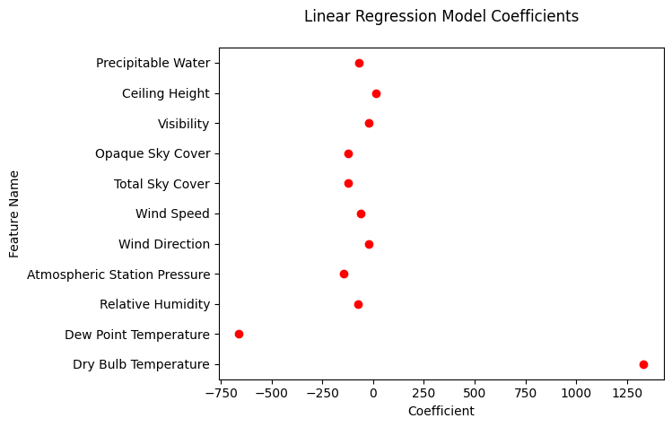

```python
print("Intercept: ", model_data.intercept_)
coeffs = model_data.coef_
y_vals = ['Dry Bulb Temperature', 'Dew Point Temperature', 'Relative Humidity',	'Atmospheric Station Pressure',	'Wind Direction',	'Wind Speed',	'Total Sky Cover', 'Opaque Sky Cover',	'Visibility',	'Ceiling Height',	'Precipitable Water']
plt.scatter(coeffs, y_vals, color= 'r')
plt.ylabel("Feature Name")
plt.xlabel("Coefficient")
plt.title("Linear Regression Model Coefficients\n")
plt.show()
```

Since we have normalized the data, the coefficient size is not affected by difference in units. Therefore in general, the larger the coefficient, the more that feature affects the target variable. According to our model then, the feature that affects Global Horizontal Radiation the most is temperature. For every one unit increase of Dry Bulb Temperature or one unit decrease of Dew Point Temperature, the mean Global Horizontal Radiation increases much more than for a one unit change of any other feature.

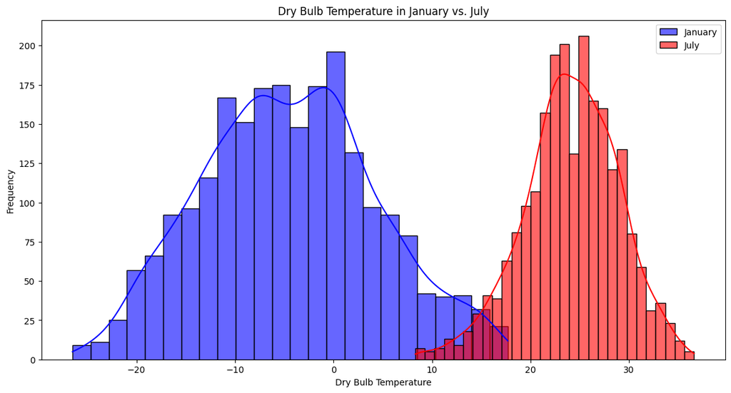

```python
plt.figure(figsize=(14, 7))
sns.histplot(january_data['Dry Bulb Temperature'], kde=True, color='blue', label='January', alpha=0.6)
sns.histplot(july_data['Dry Bulb Temperature'], kde=True, color='red', label='July', alpha=0.6)
plt.title('Dry Bulb Temperature in January vs. July')
plt.xlabel('Dry Bulb Temperature')
plt.ylabel('Frequency')
plt.legend()
plt.show()
```

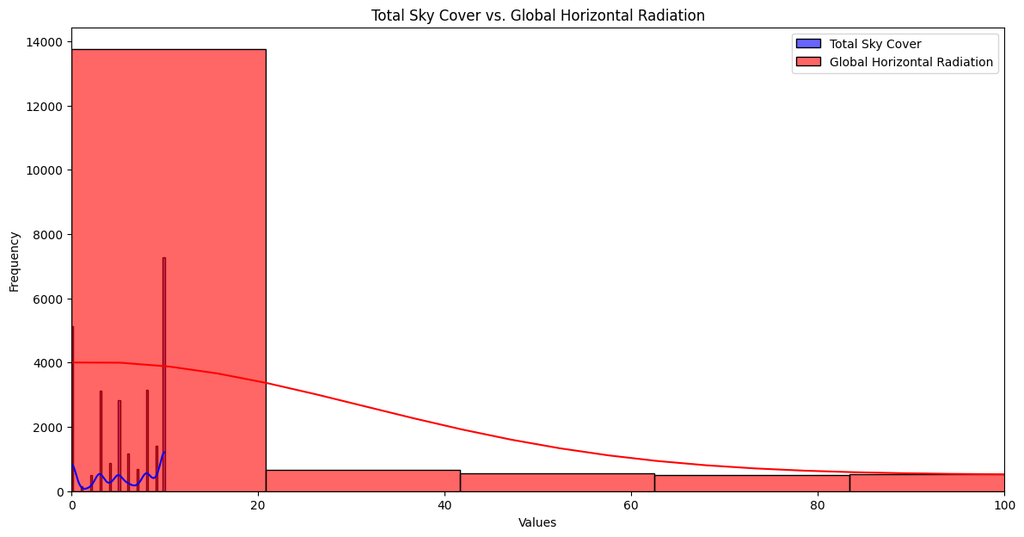

```
Regression Model Summary:
Coefficients: [-8.66711512]
Intercept: 206.15233900211393
MSE: 50109.017621405575
R²: 0.02076413188182591
```

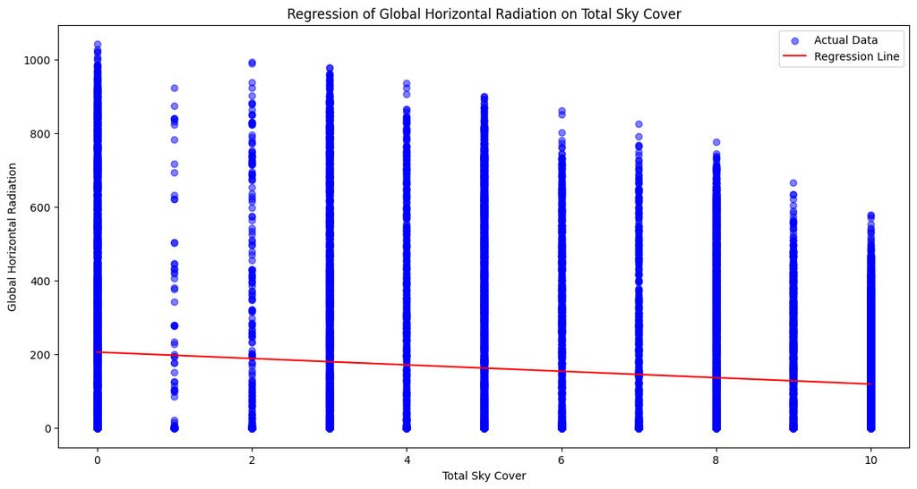

```python
# Visualization for Total Sky Cover vs. Global Horizontal Radiation
total_sky_cover = data['Total Sky Cover']
global_horizontal_radiation = data['Global Horizontal Radiation']

# Fit the regression model
X = total_sky_cover.values.reshape(-1, 1)
y = global_horizontal_radiation

model = LinearRegression().fit(X, y)

# Predict using the model
y_pred = model.predict(X)

plt.figure(figsize=(14, 7))

sns.histplot(total_sky_cover, kde=True, color='blue', label='Total Sky Cover', bins=50, alpha=0.6)
sns.histplot(global_horizontal_radiation, kde=True, color='red', label='Global Horizontal Radiation', bins=50, alpha=0.6)
plt.title('Total Sky Cover vs. Global Horizontal Radiation')
plt.xlabel('Values')
plt.ylabel('Frequency')
plt.xlim(0, 100)
plt.legend()
plt.show()

print("Regression Model Summary:")
print(f"Coefficients: {model.coef_}")
print(f"Intercept: {model.intercept_}")
print(f"MSE: {mean_squared_error(y, y_pred)}")
print(f"R²: {r2_score(y, y_pred)}")

# Scatter plot with regression line
plt.figure(figsize=(14, 7))
plt.scatter(total_sky_cover, global_horizontal_radiation, color='blue', alpha=0.5, label='Actual Data')
plt.plot(total_sky_cover, y_pred, color='red', label='Regression Line')
plt.title('Regression of Global Horizontal Radiation on Total Sky Cover')
plt.xlabel('Total Sky Cover')
plt.ylabel('Global Horizontal Radiation')
plt.legend()
plt.show()
```

Next, a simple regression model is used to analyze how variations in dry bulb temperature impact global horizontal radiation. This will help us further understand the relationship (through predictive analysis and data-driven insights), optimize solar energy systems (through more efficiency and energy production forecasting), allocate resources better, and much more.

The Mean Squared Error (MSE) indicates the average squared difference between the observed and predicted values. Lower MSE shows a better fit. The R-squared value how well the model explains the variability of the response data around its mean.

```python
data = pd.concat([ct_hartford, pa_philadelphia, me_caribou])

# Extract the relevant columns
dry_bulb_temp = data['Dry Bulb Temperature'].values.reshape(-1, 1)
global_horiz_rad = data['Global Horizontal Radiation'].values

# Split the data into training and testing sets
X_train, X_test, y_train, y_test = train_test_split(dry_bulb_temp, global_horiz_rad, test_size=0.2, random_state=42)

# Create and train the linear regression model
regressor = LinearRegression()
regressor.fit(X_train, y_train)

# Make predictions using the testing set
y_pred = regressor.predict(X_test)

# Evaluate the model
mse = mean_squared_error(y_test, y_pred)
r2 = r2_score(y_test, y_pred)

# Print the evaluation metrics
print("Mean Squared Error:", mse)
print("R-squared:", r2)
print("Intercept:", regressor.intercept_)
print("Coefficient:", regressor.coef_[0])
```

```
Mean Squared Error: 44564.436285866504
R-squared: 0.1384876271762846
Intercept: 84.05860242365301
Coefficient: 7.273391172339827
```

[figure not shown]

```python
plt.figure(figsize=(14, 8))
plt.scatter(dry_bulb_temp, global_horiz_rad, color='blue', alpha=0.5, label='Data points')
plt.plot(X_test, y_pred, color='red', linewidth=2, label='Regression line')
plt.title('Linear Regression: Dry Bulb Temperature vs Global Horizontal Radiation (Combined Data)')
plt.xlabel('Dry Bulb Temperature (°F)')
plt.ylabel('Global Horizontal Radiation (W/m^2)')
plt.legend()
plt.grid(True)
plt.show()
```

## 6. Insights and Conclusions

Comparison of weather variables:

Our heat map analysis of 12 different weather variables demonstrated that relative humidity is correlated with the most weather variables. Furthermore, relative humidity has the strongest correlation with Global Horizontal Radiation among all other variables, with lower humidity being correlated with greater Global Horizontal Radiation. Our linear regression model that predicted Global Horizontal Radiation based off the other 11 weather variables revealed that temperature has the largest effect on Global Horizontal Radiation, with higher dry bulb temperature and lower dew point temperature leading to greater radiation. While our model had a high MSE value, it had an R^2 coefficient of 0.85, signifying that the line fit the data very well. In conclusion, our comprehensive analysis of the 12 weather variables demonstrates that they all play a role in affecting solar radiation, but humidity and temperature stand out as two of the most important factors when considering solar radiation.

Dry Bulb Temperature in January vs. July:

- The coefficient of approximately 28.57 indicates that the dry bulb temperature in July is, on average, about 28.57 degrees higher than in January.
- The R² value of 0.80 suggests that 80% of the variance in temperature between January and July is explained by the model, indicating a strong relationship.
- The intercept of -4.43 shows the estimated average temperature for January when adjusted to the zero baseline.

The model indicates a significant and positive difference in temperatures between January and July.

Total Sky Cover vs. Global Horizontal Radiation:

- The coefficient value from the regression output indicates how much Global Horizontal Radiation changes on average with a one-unit increase in Total Sky Cover.
- The R² value shows the proportion of variance in Global Horizontal Radiation explained by Total Sky Cover. A higher R² value suggests a stronger relationship.
- The intercept provides the estimated value of Global Horizontal Radiation when Total Sky Cover is zero.
- By interpreting these values, we can understand the relationship between Total Sky Cover and Global Horizontal Radiation and the effectiveness of our regression model.

Dry Bulb Temperature vs. Global Horizontal Radiation

- The coefficient value from the regression is 7.27. This shows that for every 1 degree increase in Dry Bulb Temperature, the Global Horizontal Radiation increases by 7.27.
- The R-squared value is 0.138, which indicates that 13.8% of the variance in Global Horizontal Radiation can be explained by Dry Bulb Temperature. This suggests a weak linear relationship between the two variables.
- When Dry Bulb Temperature is 0 degrees, the predicted Global Horizontal Radiation is approximately 84.06